# EasyVisa_Full_Code_Notebook_1

## Problem Statement

### Business Context

Business communities in the United States are facing high demand for human resources, but one of the constant challenges is identifying and attracting the right talent, which is perhaps the most important element in remaining competitive. Companies in the United States look for hard-working, talented, and qualified individuals both locally as well as abroad.

The Immigration and Nationality Act (INA) of the US permits foreign workers to come to the United States to work on either a temporary or permanent basis. The act also protects US workers against adverse impacts on their wages or working conditions by ensuring US employers' compliance with statutory requirements when they hire foreign workers to fill workforce shortages. The immigration programs are administered by the Office of Foreign Labor Certification (OFLC).

OFLC processes job certification applications for employers seeking to bring foreign workers into the United States and grants certifications in those cases where employers can demonstrate that there are not sufficient US workers available to perform the work at wages that meet or exceed the wage paid for the occupation in the area of intended employment.

### Objective

In FY 2016, the OFLC processed 775,979 employer applications for 1,699,957 positions for temporary and permanent labor certifications. This was a nine percent increase in the overall number of processed applications from the previous year. The process of reviewing every case is becoming a tedious task as the number of applicants is increasing every year.

The increasing number of applicants every year calls for a Machine Learning based solution that can help in shortlisting the candidates having higher chances of VISA approval. OFLC has hired the firm EasyVisa for data-driven solutions. You as a data scientist at EasyVisa have to analyze the data provided and, with the help of a classification model:

- Facilitate the process of visa approvals.
- Recommend a suitable profile for the applicants for whom the visa should be certified or denied based on the drivers that significantly influence the case status.

### Data Description

The data contains the different attributes of employee and the employer. The detailed data dictionary is given below.

- case_id: ID of each visa application
- continent: Information of continent the employee
- education_of_employee: Information of education of the employee
- has_job_experience: Does the employee has any job experience? Y= Yes; N = No
- requires_job_training: Does the employee require any job training? Y = Yes; N = No
- no_of_employees: Number of employees in the employer's company
- yr_of_estab: Year in which the employer's company was established
- region_of_employment: Information of foreign worker's intended region of employment in the US.
- prevailing_wage: Average wage paid to similarly employed workers in a specific occupation in the area of intended employment. The purpose of the prevailing wage is to ensure that the foreign worker is not underpaid compared to other workers offering the same or similar service in the same area of employment.
- unit_of_wage: Unit of prevailing wage. Values include Hourly, Weekly, Monthly, and Yearly.
- full_time_position: Is the position of work full-time? Y = Full Time Position; N = Part Time Position
- case_status: Flag indicating if the Visa was certified or denied

## Installing and Importing the necessary libraries

```python
# Installing the libraries with the specified version.
!pip install -q --user numpy==1.26.4 pandas==2.2.2 matplotlib==3.8.4 scikit-learn seaborn xgboost
```

**Note**: *After running the above cell, kindly restart the notebook kernel and run all cells sequentially from the below.*

```python
# Libraries to help with reading and manipulating data
import numpy as np
import pandas as pd

# Library to split data
from sklearn.model_selection import train_test_split

# To oversample and undersample data
from imblearn.over_sampling import SMOTE
from imblearn.under_sampling import RandomUnderSampler
from sklearn.model_selection import train_test_split, StratifiedKFold, cross_val_score


# libaries to help with data visualization
import matplotlib.pyplot as plt
import seaborn as sns

# Removes the limit for the number of displayed columns
pd.set_option("display.max_columns", None)
# Sets the limit for the number of displayed rows
pd.set_option("display.max_rows", 100)

# Libraries different ensemble classifiers
from sklearn.ensemble import (
    BaggingClassifier,
    RandomForestClassifier,
    AdaBoostClassifier,
    GradientBoostingClassifier
)

from xgboost import XGBClassifier
from sklearn.tree import DecisionTreeClassifier

# Libraries to get different metric scores
from sklearn import metrics
from sklearn.metrics import (
    confusion_matrix,
    accuracy_score,
    precision_score,
    recall_score,
    f1_score,
)

# Define the scorer
from sklearn.metrics import make_scorer, f1_score
from sklearn.model_selection import RandomizedSearchCV, StratifiedKFold

# To tune a model
from sklearn.model_selection import RandomizedSearchCV
from sklearn.model_selection import GridSearchCV

# To ignore unnecessary warnings
import warnings
warnings.filterwarnings("ignore")
```

## Import Dataset

```python
# Uncomment and execute the code snippets below if the data is stored in Google Drive
from google.colab import drive
drive.mount('/content/drive')
```

```python
df = pd.read_csv('/content/drive/MyDrive/Great Learning/3. Advanced Machine Learning/Project - Advanced Machine Learning/EasyVisa.csv')
```

```python
# Copying data to another variable to avoid making changes to the original data
data = df.copy()
```

## Overview of the Dataset

#### View the first and last 5 rows of the dataset

```python
data.head()
```

|  | case_id | continent | education_of_employee | has_job_experience | requires_job_training | no_of_employees | yr_of_estab | region_of_employment | prevailing_wage | unit_of_wage | full_time_position | case_status |
| --- | --- | --- | --- | --- | --- | --- | --- | --- | --- | --- | --- | --- |
| 0 | EZYV01 | Asia | High School | N | N | 14513 | 2007 | West | 592.2029 | Hour | Y | Denied |
| 1 | EZYV02 | Asia | Master's | Y | N | 2412 | 2002 | Northeast | 83425.6500 | Year | Y | Certified |
| 2 | EZYV03 | Asia | Bachelor's | N | Y | 44444 | 2008 | West | 122996.8600 | Year | Y | Denied |
| 3 | EZYV04 | Asia | Bachelor's | N | N | 98 | 1897 | West | 83434.0300 | Year | Y | Denied |
| 4 | EZYV05 | Africa | Master's | Y | N | 1082 | 2005 | South | 149907.3900 | Year | Y | Certified |

```python
data.tail()
```

|  | case_id | continent | education_of_employee | has_job_experience | requires_job_training | no_of_employees | yr_of_estab | region_of_employment | prevailing_wage | unit_of_wage | full_time_position | case_status |
| --- | --- | --- | --- | --- | --- | --- | --- | --- | --- | --- | --- | --- |
| 25475 | EZYV25476 | Asia | Bachelor's | Y | Y | 2601 | 2008 | South | 77092.57 | Year | Y | Certified |
| 25476 | EZYV25477 | Asia | High School | Y | N | 3274 | 2006 | Northeast | 279174.79 | Year | Y | Certified |
| 25477 | EZYV25478 | Asia | Master's | Y | N | 1121 | 1910 | South | 146298.85 | Year | N | Certified |
| 25478 | EZYV25479 | Asia | Master's | Y | Y | 1918 | 1887 | West | 86154.77 | Year | Y | Certified |
| 25479 | EZYV25480 | Asia | Bachelor's | Y | N | 3195 | 1960 | Midwest | 70876.91 | Year | Y | Certified |

#### **Comment:**

- I quickly inspect a few sample rows at the top and bottom to confirm column names, data types, and see if there are any immediately obvious issues

#### Understand the shape of the dataset

```python
data.shape
```

```
(25480, 12)
```

#### **Comment:**

- The dataset has 25480 rows and 12 columns

#### Check the data types of the columns for the dataset

```python
data.info()
```

```
<class 'pandas.core.frame.DataFrame'>
RangeIndex: 25480 entries, 0 to 25479
Data columns (total 12 columns):
 #   Column                 Non-Null Count  Dtype
---  ------                 --------------  -----
 0   case_id                25480 non-null  object
 1   continent              25480 non-null  object
 2   education_of_employee  25480 non-null  object
 3   has_job_experience     25480 non-null  object
 4   requires_job_training  25480 non-null  object
 5   no_of_employees        25480 non-null  int64
 6   yr_of_estab            25480 non-null  int64
 7   region_of_employment   25480 non-null  object
 8   prevailing_wage        25480 non-null  float64
 9   unit_of_wage           25480 non-null  object
 10  full_time_position     25480 non-null  object
 11  case_status            25480 non-null  object
dtypes: float64(1), int64(2), object(9)
memory usage: 2.3+ MB
```

#### **Comment:**

- No Nulls: Every column shows “25480 non-null,” so there are no missing values—great.
- Categoricals: Nine columns are object, including continent, education_of_employee, has_job_experience, etc. While no_of_employees and yr_of_estab as int64.

```python
# checking for duplicate values
data.duplicated().sum()
```

```
0
```

#### **Comment:**

- There are no duplicate rows in the dataset — all observations are unique

#### Let's check the missing values in data

```python
print(df.isnull().sum())
```

```
case_id                  0
continent                0
education_of_employee    0
has_job_experience       0
requires_job_training    0
no_of_employees          0
yr_of_estab              0
region_of_employment     0
prevailing_wage          0
unit_of_wage             0
full_time_position       0
case_status              0
dtype: int64
```

#### **Comment:**

- Every column (e.g., case_id, continent, education_of_employee, etc.) has 0 missing values.

## Exploratory Data Analysis (EDA)

#### Let's check the statistical summary of the data

```python
data.describe(include='all').T
```

|  | count | unique | top | freq | mean | std | min | 25% | 50% | 75% | max |
| --- | --- | --- | --- | --- | --- | --- | --- | --- | --- | --- | --- |
| case_id | 25480 | 25480 | EZYV01 | 1 | NaN | NaN | NaN | NaN | NaN | NaN | NaN |
| continent | 25480 | 6 | Asia | 16861 | NaN | NaN | NaN | NaN | NaN | NaN | NaN |
| education_of_employee | 25480 | 4 | Bachelor's | 10234 | NaN | NaN | NaN | NaN | NaN | NaN | NaN |
| has_job_experience | 25480 | 2 | Y | 14802 | NaN | NaN | NaN | NaN | NaN | NaN | NaN |
| requires_job_training | 25480 | 2 | N | 22525 | NaN | NaN | NaN | NaN | NaN | NaN | NaN |
| no_of_employees | 25480.0 | NaN | NaN | NaN | 5667.04321 | 22877.928848 | -26.0 | 1022.0 | 2109.0 | 3504.0 | 602069.0 |
| yr_of_estab | 25480.0 | NaN | NaN | NaN | 1979.409929 | 42.366929 | 1800.0 | 1976.0 | 1997.0 | 2005.0 | 2016.0 |
| region_of_employment | 25480 | 5 | Northeast | 7195 | NaN | NaN | NaN | NaN | NaN | NaN | NaN |
| prevailing_wage | 25480.0 | NaN | NaN | NaN | 74455.814592 | 52815.942327 | 2.1367 | 34015.48 | 70308.21 | 107735.5125 | 319210.27 |
| unit_of_wage | 25480 | 4 | Year | 22962 | NaN | NaN | NaN | NaN | NaN | NaN | NaN |
| full_time_position | 25480 | 2 | Y | 22773 | NaN | NaN | NaN | NaN | NaN | NaN | NaN |
| case_status | 25480 | 2 | Certified | 17018 | NaN | NaN | NaN | NaN | NaN | NaN | NaN |

#### Fixing the negative values in number of employees columns

```python
data.loc[data['no_of_employees'] < 0].shape
```

```
(33, 12)
```

#### **Comment:**

- There are 33 rows in your dataset where no_of_employees is negative. This is invalid, and sure the negative sign is just a data entry error. I will be using the absolute value to correct this.

```python
# taking the absolute values for number of employees
data["no_of_employees"] = abs(data["no_of_employees"])
```

#### **Comment:**

- This corrects invalid negative values in the no_of_employees column by ensuring all entries represent non-negative employee counts, which makes sense logically (we can't have negative employees).

```python
# checking the distribution of the target variable
data["case_status"].value_counts(1)
```

| case_status | proportion |
| --- | --- |
| Certified | 0.667896 |
| Denied | 0.332104 |

**dtype:** float64

#### **Comment:**

- This shows that the dataset is somewhat imbalanced, with Certified cases being roughly twice as common as Denied cases i.e.
  - About 66.79% of the cases are Certified.
  - About 33.21% of the cases are Denied.

#### Let's check the count of each unique category in each of the categorical variables

```python
# Making a list of all categorical variables
categorical_col = list(data.select_dtypes("object").columns)

# Printing number of count of each unique value in each column
for column in categorical_col:
    print(data[column].value_counts())
    print("*" * 150)
```

```
case_id
EZYV01       1
EZYV16995    1
EZYV16993    1
EZYV16992    1
EZYV16991    1
            ..
EZYV8492     1
EZYV8491     1
EZYV8490     1
EZYV8489     1
EZYV25480    1
Name: count, Length: 25480, dtype: int64
continent
Asia             16861
Europe            3732
North America     3292
South America      852
Africa             551
Oceania            192
Name: count, dtype: int64
education_of_employee
Bachelor's     10234
Master's        9634
High School     3420
Doctorate       2192
Name: count, dtype: int64
has_job_experience
Y    14802
N    10678
Name: count, dtype: int64
requires_job_training
N    22525
Y     2955
Name: count, dtype: int64
region_of_employment
Northeast    7195
South        7017
West         6586
Midwest      4307
Island        375
Name: count, dtype: int64
unit_of_wage
Year     22962
Hour      2157
Week       272
Month       89
Name: count, dtype: int64
full_time_position
Y    22773
N     2707
Name: count, dtype: int64
case_status
Certified    17018
Denied        8462
Name: count, dtype: int64
```

#### **Comment:**

- Most categorical variables show moderate to strong imbalance—such as in continent, unit_of_wage, and requires_job_training—while case_id is a unique identifier and should be excluded from modeling. The target variable case_status is moderately imbalanced (67% Certified, 33% Denied), suggesting a need to consider class-balancing techniques during modeling.

### Univariate Analysis

```python
def histogram_boxplot(data, feature, figsize=(15, 10), kde=False, bins=None):
    """
    Boxplot and histogram combined

    data: dataframe
    feature: dataframe column
    figsize: size of figure (default (15,10))
    kde: whether to show the density curve (default False)
    bins: number of bins for histogram (default None)
    """
    f2, (ax_box2, ax_hist2) = plt.subplots(
        nrows=2,  # Number of rows of the subplot grid= 2
        sharex=True,  # x-axis will be shared among all subplots
        gridspec_kw={"height_ratios": (0.25, 0.75)},
        figsize=figsize,
    )  # creating the 2 subplots
    sns.boxplot(
        data=data, x=feature, ax=ax_box2, showmeans=True, color="violet"
    )  # boxplot will be created and a triangle will indicate the mean value of the column
    sns.histplot(
        data=data, x=feature, kde=kde, ax=ax_hist2, bins=bins
    ) if bins else sns.histplot(
        data=data, x=feature, kde=kde, ax=ax_hist2
    )  # For histogram
    ax_hist2.axvline(
        data[feature].mean(), color="green", linestyle="--"
    )  # Add mean to the histogram
    ax_hist2.axvline(
        data[feature].median(), color="black", linestyle="-"
    )  # Add median to the histogram
```

```python
# function to create labeled barplots


def labeled_barplot(data, feature, perc=False, n=None):
    """
    Barplot with percentage at the top

    data: dataframe
    feature: dataframe column
    perc: whether to display percentages instead of count (default is False)
    n: displays the top n category levels (default is None, i.e., display all levels)
    """

    total = len(data[feature])  # length of the column
    count = data[feature].nunique()
    if n is None:
        plt.figure(figsize=(count + 1, 5))
    else:
        plt.figure(figsize=(n + 1, 5))

    plt.xticks(rotation=90, fontsize=15)
    ax = sns.countplot(
        data=data,
        x=feature,
        palette="Paired",
        order=data[feature].value_counts().index[:n].sort_values(),
    )

    for p in ax.patches:
        if perc == True:
            label = "{:.1f}%".format(
                100 * p.get_height() / total
            )  # percentage of each class of the category
        else:
            label = p.get_height()  # count of each level of the category

        x = p.get_x() + p.get_width() / 2  # width of the plot
        y = p.get_height()  # height of the plot

        ax.annotate(
            label,
            (x, y),
            ha="center",
            va="center",
            size=12,
            xytext=(0, 5),
            textcoords="offset points",
        )  # annotate the percentage

    plt.show()  # show the plot
```

#### Observations on education of employee

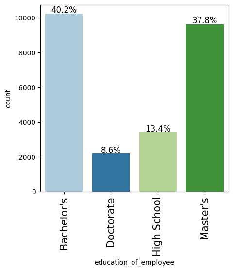

```python
labeled_barplot(data, "education_of_employee", perc=True)
```

#### **Comment:**

- Highly Skilled Applicant Pool:

  More than 78% of applicants hold at least a Bachelor’s degree, aligning with the INA’s preference for qualified and specialized talent.

  This concentration of educated individuals may explain a higher rate of certifications, especially if education is a key approval factor.
- Feature Relevance for Classification:

  education_of_employee is likely a significant predictor of case_status, as educational attainment often correlates with job readiness and wage expectations.

#### Observations on region of employment

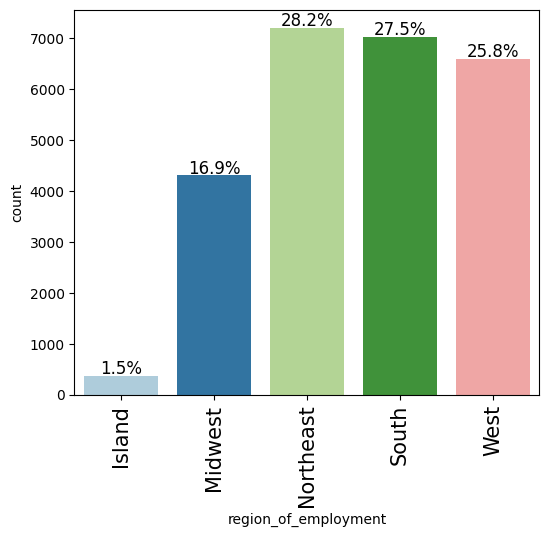

```python
# Creating barplot for region of employment

labeled_barplot(data,"region_of_employment", perc=True)
```

#### **Comment:**

- The plot shows that visa applications are most concentrated in the Northeast (28.2%), South (27.5%), and West (25.8%), which together account for over 81% of employment regions. The Midwest represents 16.9%, while Island regions account for only 1.5%, indicating minimal demand there. This regional concentration reflects where foreign labor is most needed and should be considered when modeling visa approval outcomes.

#### Observations on job experience

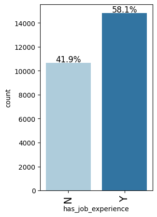

```python
# Creating barplot for job experience

labeled_barplot(data,"has_job_experience", perc=True)
```

#### **Comment:**

- The plot shows the distribution of applicants based on job experience:
  - 58.1% of applicants have prior job experience, while 41.9% do not.

#### Observations on case status

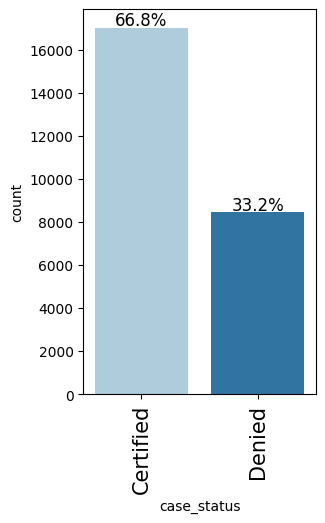

```python
# Creating barplot for case status
labeled_barplot(data,"case_status", perc=True)
```

#### **Comment:**

- The plot displays the distribution of visa application outcomes:
- 66.8% of applications were Certified.
- 33.2% were Denied.

### Bivariate Analysis

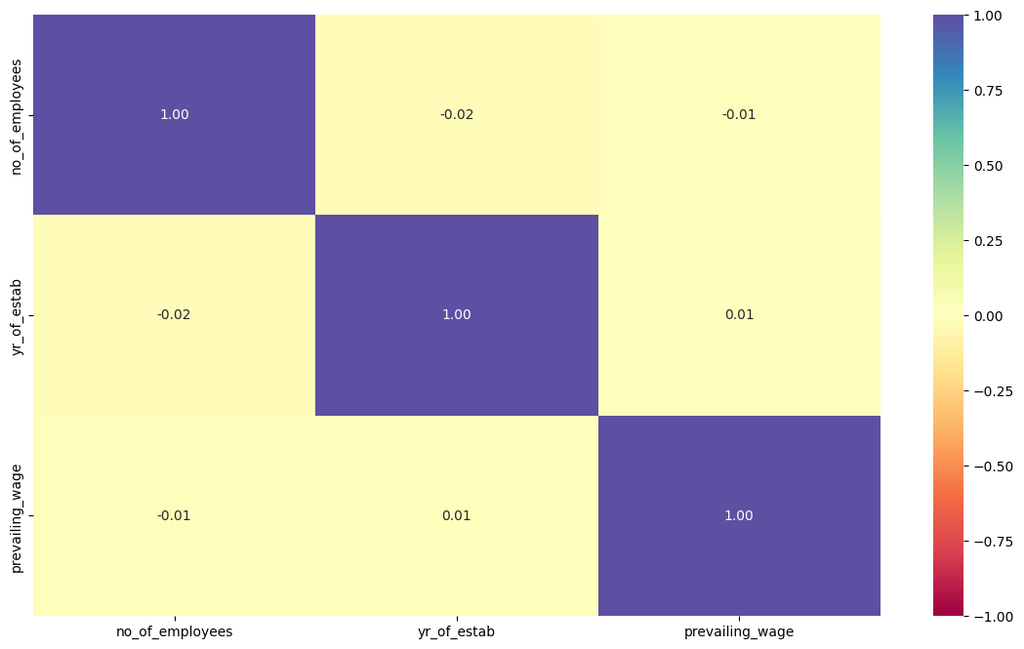

```python
cols_list = data.select_dtypes(include=np.number).columns.tolist()

plt.figure(figsize=(14, 8))
sns.heatmap(
    data[cols_list].corr(), annot=True, vmin=-1, vmax=1, fmt=".2f", cmap="Spectral"
)
plt.show()
```

#### **Comment:**

- All off-diagonal correlation values are very close to 0 (ranging from -0.02 to 0.01), indicating no significant linear relationship between any pair of variables.
- Each variable is independent in terms of linear association with the others, meaning there is no risk of multicollinearity among them.

**Creating functions that will help us with further analysis.**

```python
### function to plot distributions wrt target


def distribution_plot_wrt_target(data, predictor, target):

    fig, axs = plt.subplots(2, 2, figsize=(12, 10))

    target_uniq = data[target].unique()

    axs[0, 0].set_title("Distribution of target for target=" + str(target_uniq[0]))
    sns.histplot(
        data=data[data[target] == target_uniq[0]],
        x=predictor,
        kde=True,
        ax=axs[0, 0],
        color="teal",
        stat="density",
    )

    axs[0, 1].set_title("Distribution of target for target=" + str(target_uniq[1]))
    sns.histplot(
        data=data[data[target] == target_uniq[1]],
        x=predictor,
        kde=True,
        ax=axs[0, 1],
        color="orange",
        stat="density",
    )

    axs[1, 0].set_title("Boxplot w.r.t target")
    sns.boxplot(data=data, x=target, y=predictor, ax=axs[1, 0], palette="gist_rainbow")

    axs[1, 1].set_title("Boxplot (without outliers) w.r.t target")
    sns.boxplot(
        data=data,
        x=target,
        y=predictor,
        ax=axs[1, 1],
        showfliers=False,
        palette="gist_rainbow",
    )

    plt.tight_layout()
    plt.show()
```

```python
def stacked_barplot(data, predictor, target):
    """
    Print the category counts and plot a stacked bar chart

    data: dataframe
    predictor: independent variable
    target: target variable
    """
    count = data[predictor].nunique()
    sorter = data[target].value_counts().index[-1]
    tab1 = pd.crosstab(data[predictor], data[target], margins=True).sort_values(
        by=sorter, ascending=False
    )
    print(tab1)
    print("-" * 120)
    tab = pd.crosstab(data[predictor], data[target], normalize="index").sort_values(
        by=sorter, ascending=False
    )
    tab.plot(kind="bar", stacked=True, figsize=(count + 5, 5))
    plt.legend(
        loc="lower left", frameon=False,
    )
    plt.legend(loc="upper left", bbox_to_anchor=(1, 1))
    plt.show()
```

#### Does higher education increase the chances of visa certification for well-paid jobs abroad?

```
case_status            Certified  Denied    All
education_of_employee
All                        17018    8462  25480
Bachelor's                  6367    3867  10234
High School                 1164    2256   3420
Master's                    7575    2059   9634
Doctorate                   1912     280   2192
------------------------------------------------------------------------------------------------------------------------
```

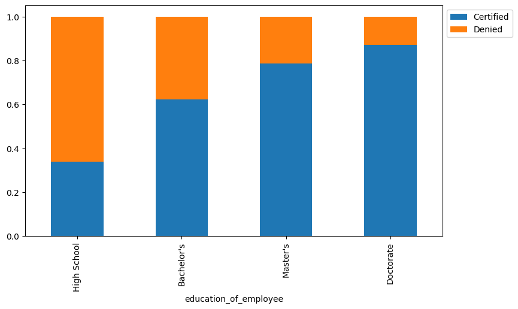

```python
stacked_barplot(data, "education_of_employee", "case_status")
```

#### **Comment:**

- Applicants with higher education levels have significantly better visa approval rates:
- Doctorate: 87.3% approved (1912 out of 2192)
- Master’s: 78.6% approved (7575 out of 9634)
- Bachelor’s: 62.2% approved (6367 out of 10234)
- High School: only 34.0% approved (1164 out of 3420)
- This clearly shows that visa approval likelihood increases with education level, making education_of_employee a key driver in the certification decision.

#### How does visa status vary across different continents?

```
case_status    Certified  Denied    All
continent
All                17018    8462  25480
Asia               11012    5849  16861
North America       2037    1255   3292
Europe              2957     775   3732
South America        493     359    852
Africa               397     154    551
Oceania              122      70    192
------------------------------------------------------------------------------------------------------------------------
```

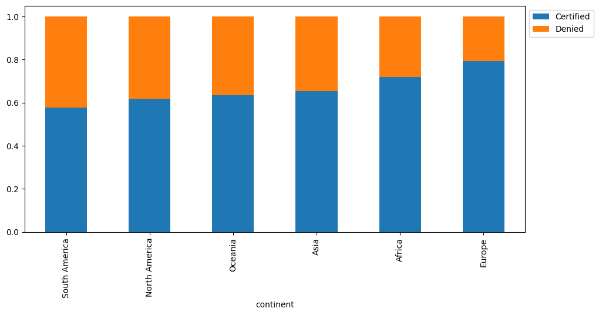

```python
# Creating stacked barplot for continent and case status

stacked_barplot(data,"continent","case_status")
```

#### **Comment:**

- The stacked bar plot and table show visa certification outcomes by continent.
- Europe and Africa have the highest approval rates at 79.3% and 72.0%, respectively.
- South America has the lowest approval rate at 57.9%.
- While Asia contributes the largest number of applications (16,861), its approval rate is moderate (65.3%).

#### Does having prior work experience influence the chances of visa certification for career opportunities abroad?

```
has_job_experience      N      Y    All
case_status
All                 10678  14802  25480
Certified            5994  11024  17018
Denied               4684   3778   8462
------------------------------------------------------------------------------------------------------------------------
```

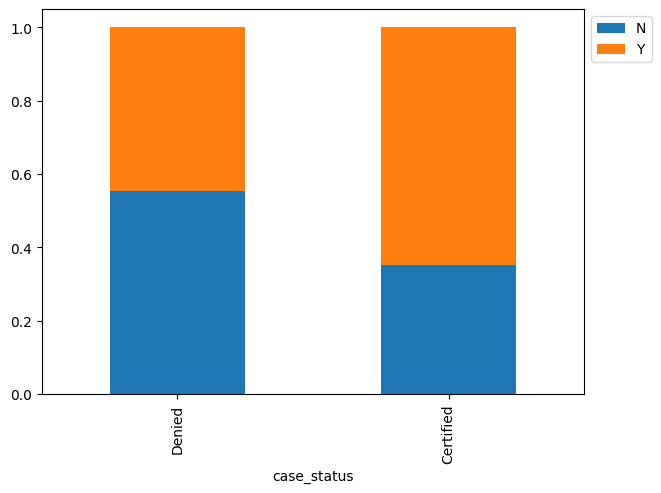

```python
# Creating stacked barplot for case status and job experience

stacked_barplot(data,"case_status","has_job_experience")
```

#### Is the prevailing wage consistent across all regions of the US?

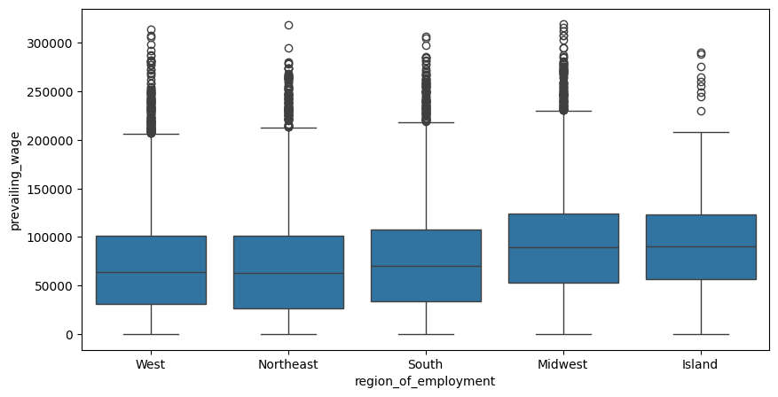

```python
# Creating boxplot for region of employment and prevailing wage

plt.figure(figsize=(10, 5))
sns.boxplot(data=data, x="region_of_employment", y="prevailing_wage")
plt.show()
```

#### Does visa status vary with changes in the prevailing wage set to protect both local talent and foreign workers?

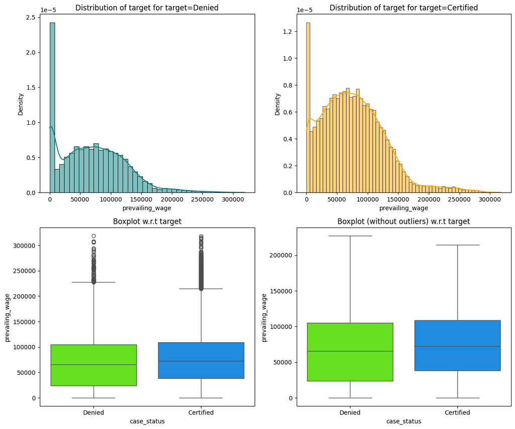

```python
# Distribution of prevailing wage and case status

distribution_plot_wrt_target(data,"prevailing_wage","case_status")
```

#### Does the unit of prevailing wage (Hourly, Weekly, etc.) have any impact on the likelihood of visa application certification?

```
case_status   Certified  Denied    All
unit_of_wage
All               17018    8462  25480
Year              16047    6915  22962
Hour                747    1410   2157
Week                169     103    272
Month                55      34     89
------------------------------------------------------------------------------------------------------------------------
```

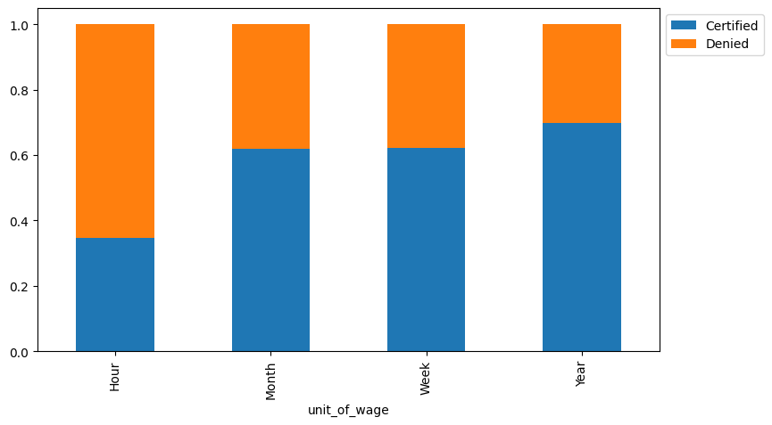

```python
#  To create stacked barplot for unit of wage and case status

stacked_barplot(data,"unit_of_wage","case_status")
```

#### **Comment:**

- The Yearly wage unit is most common (90%+ of all entries) and shows the highest approval rate (~70%).
- Hourly wage applicants are more likely to be denied, with an approval rate of just 34.6%.
- Weekly and Monthly units are rare but show moderate approval rates (~62%).

## Data Pre-processing

### Outlier Check

```python
# Let's check the counts of unique categories
for col in data.select_dtypes(include='object').columns:
    print(f"Counts for {col}:\n", data[col].value_counts(), "\n")
```

```
Counts for case_id:
 case_id
EZYV01       1
EZYV16995    1
EZYV16993    1
EZYV16992    1
EZYV16991    1
            ..
EZYV8492     1
EZYV8491     1
EZYV8490     1
EZYV8489     1
EZYV25480    1
Name: count, Length: 25480, dtype: int64

Counts for continent:
 continent
Asia             16861
Europe            3732
North America     3292
South America      852
Africa             551
Oceania            192
Name: count, dtype: int64

Counts for education_of_employee:
 education_of_employee
Bachelor's     10234
Master's        9634
High School     3420
Doctorate       2192
Name: count, dtype: int64

Counts for has_job_experience:
 has_job_experience
Y    14802
N    10678
Name: count, dtype: int64

Counts for requires_job_training:
```

[output cut: 18 more lines]

```
Week       272
Month       89
Name: count, dtype: int64

Counts for full_time_position:
 full_time_position
Y    22773
N     2707
Name: count, dtype: int64

Counts for case_status:
 case_status
Certified    17018
Denied        8462
Name: count, dtype: int64
```

#### **Comment:**

- Most categorical features show imbalance:
- 66% of applicants are from Asia,
- 78% hold a Bachelor’s or Master’s,
- 58% have job experience,
- 88% do not require job training,
- 90% report wages yearly,
- and 89% are for full-time roles.

  The target variable case_status is 66.8% Certified and 33.2% Denied, indicating a moderate class imbalance. case_id has all unique values and should be excluded from modeling.

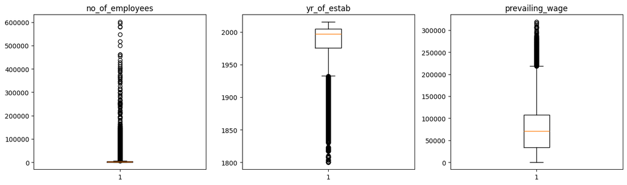

```python
# Outlier detection using boxplot
numeric_columns = data.select_dtypes(include=np.number).columns.tolist()


plt.figure(figsize=(18, 15))

for i, variable in enumerate(numeric_columns):
    plt.subplot(4, 4, i + 1)
    plt.boxplot(data[variable], whis=1.5)
    plt.tight_layout()
    plt.title(variable)

plt.show()
```

#### **Comment:**

- All three numeric features show significant outliers, especially in:
- no_of_employees (very large companies),
- and prevailing_wage (high-paying roles).
- Since the model uses tree-based ensemble techniques (Bagging, Random Forest, GBM, AdaBoost, XGBoost), outliers are less of a concern compared to linear models because:
- Ensemble models like Random Forest and Boosting are robust to extreme values as long as they are not systematically skewed or erroneous.

### Data Preparation for modeling

#### Drop case_id Column

```python
# Drop unnecessary column
data.drop('case_id', axis=1, inplace=True)
```

#### **Comment:**

```python
# Encode target
data["case_status"] = data["case_status"].apply(lambda x: 1 if x == "Certified" else 0)
```

#### **Comment:**

- I convert case_status to a numeric binary format (1 = Certified, 0 = Denied), which is crucial for compatibility with tree-based ensemble models that expect numeric labels

```python
# Drop case status from the data
X = data.drop(['case_status'],axis=1)
y = data['case_status']
```

#### **Comment:**

- This step correctly separates predictors (X) from the target (y), which is essential for training reliable ensemble models without data leakage.

```python
print("X shape:", X.shape)
print("y distribution:\n", y.value_counts(normalize=True))
```

```
X shape: (25480, 10)
y distribution:
 case_status
1    0.667896
0    0.332104
Name: proportion, dtype: float64
```

#### **Comment:**

- There are 10 features and 25,480 records, with the target showing 66.8% Certified vs 33.2% Denied. Ensemble models can proceed, but slight class imbalance may require tuning or resampling to optimize for fairness and minority class recall.

#### Encode Binary Columns

```python
# Using One‐Hot Encode
X = pd.get_dummies(X,drop_first=True)
```

#### **Comment:**

- This step applies one-hot encoding to all categorical features in X, converting them into binary dummy variables, and uses drop_first=True to avoid multicollinearity by dropping the first category in each encoded feature.

```python
# Complete the code to split the dataset into train and valid with a ratio of 7:3
X_train, X_val, y_train, y_val = train_test_split(
    X, y, test_size=0.30, random_state=1, stratify=y
)

# # Complete the code to split the dataset into valid and test with a ratio of 9:1
X_val,X_test,y_val,y_test = train_test_split(
    X_val,y_val,test_size=0.10,random_state=1,stratify=y_val
)
```

#### **Comment:**

- The dataset is split into 70% train, 27% validation, and 3% test while maintaining class balance. This structure supports reliable training, tuning, and evaluation of ensemble models without data leakage or distribution bias.
- This setup provides:
- Ample data (70%) to train ensemble models, which typically need large datasets to stabilize trees.
- A clean validation set (27%) for tuning hyperparameters and comparing models like RandomForest, XGBoost, etc.
- A tiny holdout test set (3%) for final, unbiased model evaluation.
- Use of stratify=y ensures class imbalance is preserved across all splits, which is critical for fair evaluation in imbalanced classification tasks.

```python
print("Shape of Training set : ", X_train.shape)
print("Shape of Validation set : ", X_val.shape)
print("Shape of test set : ", X_test.shape)
print("Percentage of classes in training set:")
print(y_train.value_counts(normalize=True))
print("Percentage of classes in validation set:")
print(y_val.value_counts(normalize=True))
print("Percentage of classes in test set:")
print(y_test.value_counts(normalize=True))
```

```
Shape of Training set :  (17836, 21)
Shape of Validation set :  (6879, 21)
Shape of test set :  (765, 21)
Percentage of classes in training set:
case_status
1    0.667919
0    0.332081
Name: proportion, dtype: float64
Percentage of classes in validation set:
case_status
1    0.66783
0    0.33217
Name: proportion, dtype: float64
Percentage of classes in test set:
case_status
1    0.667974
0    0.332026
Name: proportion, dtype: float64
```

#### **Comment:**

- The training, validation, and test sets retain nearly identical class distributions (~66.8% Certified, ~33.2% Denied), ensuring fair and consistent evaluation for ensemble models trained on 21 features. The data is well-prepared for modeling.

## Model Building

### Model Evaluation Criterion

- Choose the primary metric to evaluate the model on
- Elaborate on the rationale behind choosing the metric

**Primary Evaluation Metric: F1-Score**

#### Defining scorer to be used for cross-validation and hyperparameter tuning

```python
# Selected Metric
f1_scorer = make_scorer(f1_score, pos_label=1)

# Parameter grid for tuning Random Forest (example)
parameters = {
    'n_estimators': [100, 200],
    'max_depth': [None, 10, 20],
    'min_samples_split': [2, 5],
}

# Model instantiation with reproducibility
rf1 = RandomForestClassifier(random_state=1)

# Train model (can be with original, SMOTE, or undersampled data)
rf1.fit(X_train, y_train)
```

```
RandomForestClassifier(random_state=1)
```

#### **Comment:**

- The F1-score is chosen as the primary metric to evaluate model performance. This is a deliberate choice to balance two competing business needs in the OFLC visa certification process:
- High Recall (Sensitivity): To minimize the number of qualified visa applicants wrongly rejected (false negatives). These cases can result in missed opportunities for U.S. employers seeking talent abroad.
- Strong Precision: To limit the number of unqualified applications incorrectly certified (false positives), which could lead to non-compliance with U.S. labor protection laws.
- Using Recall alone may result in many false approvals.
- Accuracy is misleading in imbalanced datasets (66.8% Certified vs. 33.2% Denied).
- F1-score is the most balanced metric for this classification task.
- It also defines a parameter grid for tuning:
- n_estimators: Number of trees, max_depth: Tree depth, min_samples_split: Minimum samples required to split a node

#### **Metrics and Confusion Matrix Functions**

First, let's create functions to calculate different metrics and confusion matrix so that we don't have to use the same code repeatedly for each model.

- The `model_performance_classification_sklearn` function will be used to check the model performance of models.
- The `confusion_matrix_sklearn` function will be used to plot the confusion matrix.

```python
# defining a function to compute different metrics to check performance of a classification model built using sklearn


def model_performance_classification_sklearn(model, X, y_true):
    """
    Compute accuracy, recall, precision, and F1 for a fitted sklearn classifier.
    """
    y_pred = model.predict(X)
    acc = accuracy_score(y_true, y_pred)
    rec = recall_score(y_true, y_pred)
    prec = precision_score(y_true, y_pred)
    f1 = f1_score(y_true, y_pred)
    df_perf = pd.DataFrame(
        {"Accuracy": [acc], "Recall": [rec], "Precision": [prec], "F1": [f1]}
    )
    return df_perf
```

```python
# Defining a function to generate confusion matrix metrics to evaluate the performance of classification model built using scikit-learn
def confusion_matrix_sklearn(model, X, y_true):
    """
    Plot confusion matrix with raw counts and percentages.
    """
    y_pred = model.predict(X)
    cm = confusion_matrix(y_true, y_pred)
    labels = np.asarray(
        [
            [
                f"{item}\n{item / cm.flatten().sum():.2%}"
                for item in cm.flatten()
            ]
        ]
    ).reshape(2, 2)
    plt.figure(figsize=(6, 4))
    sns.heatmap(cm, annot=labels, fmt="", cmap="Blues")
    plt.ylabel("True label")
    plt.xlabel("Predicted label")
    plt.show()
```

#### GridSearch Function

```python
# Run the grid search
grid_obj = GridSearchCV(rf1, parameters, scoring=f1_scorer, cv=5, n_jobs= 1, verbose = 2)
# verbose = 2 tells about the number of fits, which can give an idea of how long will the model take in tuning
# n_jobs = -1 so that all CPU cores can be run parallelly to optimize the Search

grid_obj = grid_obj.fit(X_train, y_train)

# Print the best combination of parameters
print(grid_obj.best_params_)
```

[output not shown]

#### **Comment:**

**We are now done with pre-processing and evaluation criterion, so let's start building the model.**

### Model building with Original data (Untuned)

```
=== Original Models: Validation Performance ===
```

| Model | Accuracy | Recall | Precision | F1 |
| --- | --- | --- | --- | --- |
| Bagging_Orig | 0.691089 | 0.763822 | 0.771378 | 0.767582 |
| RandomForest_Orig | 0.718418 | 0.828907 | 0.767897 | 0.797236 |
| GBM_Orig | 0.742841 | 0.874619 | 0.771061 | 0.819582 |
| AdaBoost_Orig | 0.733682 | 0.883108 | 0.758034 | 0.815805 |
| XGBoost_Orig | 0.728740 | 0.849369 | 0.768716 | 0.807032 |
| DecisionTree_Orig | 0.665940 | 0.741402 | 0.754207 | 0.747750 |

```
=== Original Models: Test Performance ===
```

| Model | Accuracy | Recall | Precision | F1 |
| --- | --- | --- | --- | --- |
| Bagging_Orig | 0.695425 | 0.767123 | 0.774704 | 0.770895 |
| RandomForest_Orig | 0.742484 | 0.861057 | 0.777385 | 0.817084 |
| GBM_Orig | 0.762092 | 0.888454 | 0.784111 | 0.833028 |
| AdaBoost_Orig | 0.750327 | 0.900196 | 0.766667 | 0.828083 |
| XGBoost_Orig | 0.741176 | 0.870841 | 0.771231 | 0.818015 |
| DecisionTree_Orig | 0.654902 | 0.755382 | 0.735238 | 0.745174 |

```
Bagging_Orig — Validation Confusion Matrix:
```

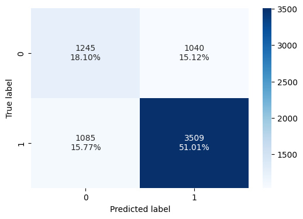

```
Bagging_Orig — Test Confusion Matrix:
```

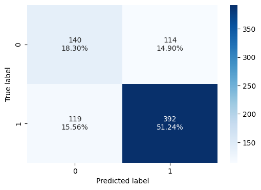

```
RandomForest_Orig — Validation Confusion Matrix:
```

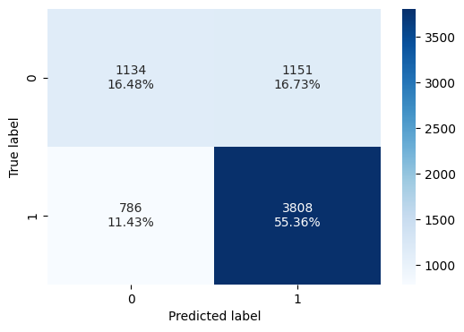

```
RandomForest_Orig — Test Confusion Matrix:
```

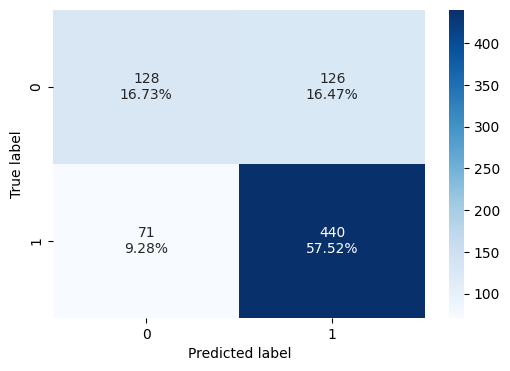

```
GBM_Orig — Validation Confusion Matrix:
```

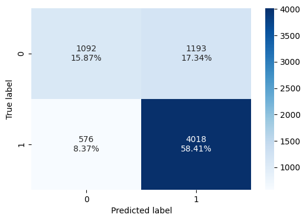

```
GBM_Orig — Test Confusion Matrix:
```

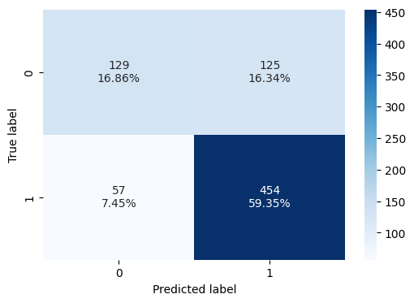

```
AdaBoost_Orig — Validation Confusion Matrix:
```

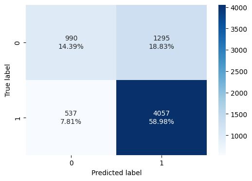

```
AdaBoost_Orig — Test Confusion Matrix:
```

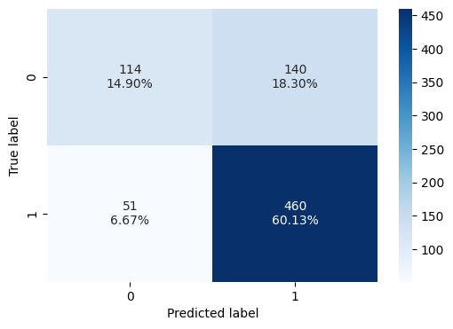

```
XGBoost_Orig — Validation Confusion Matrix:
```

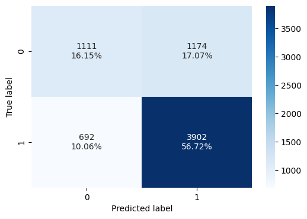

```
XGBoost_Orig — Test Confusion Matrix:
```

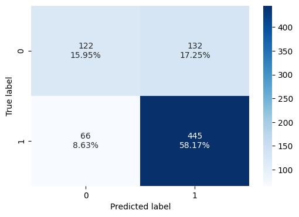

```
DecisionTree_Orig — Validation Confusion Matrix:
```

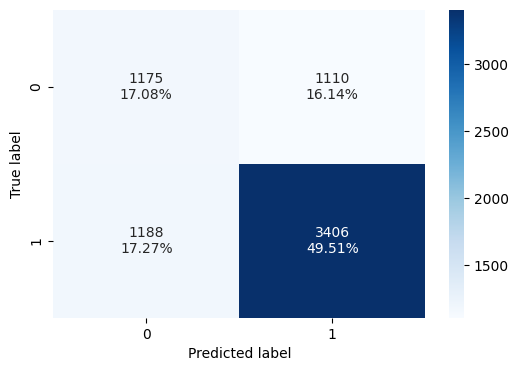

```
DecisionTree_Orig — Test Confusion Matrix:
```

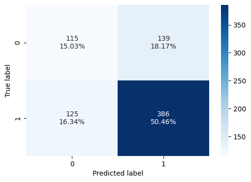

```python
models_orig = {
    "Bagging": BaggingClassifier(random_state=1),
    "RandomForest": RandomForestClassifier(random_state=1),
    "GBM": GradientBoostingClassifier(random_state=1),
    "AdaBoost": AdaBoostClassifier(random_state=1),
    "XGBoost": XGBClassifier(random_state=1, eval_metric="logloss", use_label_encoder=False),
    "DecisionTree": DecisionTreeClassifier(random_state=1),
}

performance_orig_val = []
performance_orig_test = []

# Train and collect performance metrics first
for name, model in models_orig.items():
    model.fit(X_train, y_train)

    # Validation performance
    perf_val = model_performance_classification_sklearn(model, X_val, y_val)
    perf_val["Model"] = name + "_Orig"
    performance_orig_val.append(perf_val)

    # Test performance
    perf_test = model_performance_classification_sklearn(model, X_test, y_test)
    perf_test["Model"] = name + "_Orig"
    performance_orig_test.append(perf_test)

# Convert to DataFrame and display performance tables
performance_orig_val_df = pd.concat(performance_orig_val).set_index("Model")
performance_orig_test_df = pd.concat(performance_orig_test).set_index("Model")

print("=== Original Models: Validation Performance ===")
display(performance_orig_val_df)

print("\n=== Original Models: Test Performance ===")
display(performance_orig_test_df)

# Now show confusion matrices after performance metrics
for name, model in models_orig.items():
    print(f"\n{name}_Orig — Validation Confusion Matrix:")
    confusion_matrix_sklearn(model, X_val, y_val)

    print(f"{name}_Orig — Test Confusion Matrix:")
    confusion_matrix_sklearn(model, X_test, y_test)
```

#### **Comment:**

#### 1. **BaggingClassifier_Orig**

- Bagging achieved an F1 score of 0.768 (validation) and 0.771 (test), with recall around 76% and precision near 77% across both sets. It offers consistent but moderate performance, making it a safe but less aggressive model for OFLC’s visa shortlisting.
- **Confusion Matrix Insight:**
- Correctly classified a majority of Certified applications, but moderate number of Denied cases were incorrectly labeled as Certified.
- True Positives (TP): High, but not the best among models.
- False Negatives (FN): Still present → Some eligible applicants were missed.
- **Business Impact:**
- In the context of OFLC’s goal to streamline visa certification, Bagging provides balanced but conservative performance. It may not be ideal where maximizing approved candidates is critical, but can serve as a safe baseline model where both certification and denial are equally sensitive decisions.

#### **3. GradientBoostingClassifier_Orig (GBM)**

- GBM achieved the highest overall performance, with F1 scores of 0.820 (validation) and 0.833 (test), recall up to 88.9%, and precision over 78%. It is the best candidate for OFLC when minimizing missed certifications is critical.
- **Confusion Matrix Insight:**
- Strong TP rate, slightly higher FP compared to RF.
- Best at identifying Certified applicants but may pass a few Denied ones.
- Delivers high coverage of eligible cases.
- Business Impact:
- Perfect for OFLC’s mission of identifying qualified foreign workers quickly. With the highest F1, GBM ensures maximum approvals with minimal oversight, aligning with the push for automation amid rising application volumes. It's ideal when recall is more valuable than occasional false positives.

- AdaBoost had the highest recall, reaching 90.0% on the test set, with F1 scores of 0.816 (validation) and 0.828 (test). Precision hovered around 76.6%, making it ideal for OFLC workflows focused on ensuring strong applicants are not overlooked, even if some denials are misclassified.
- **Confusion Matrix Insight:**
- Lowest false negatives — very few Certified applications are missed.
- Slightly higher false positives — some Denied cases may be classified as Certified.
- Prioritizes not missing strong applicants, even if it flags a few marginal ones.
- **Business Impact:**
- In OFLC’s context, AdaBoost is highly suited for candidate shortlisting tools, where missing a qualified applicant is more costly than extra review of Denied ones. It supports frontline automation and can drastically reduce manual review load by surfacing strong candidates confidently.

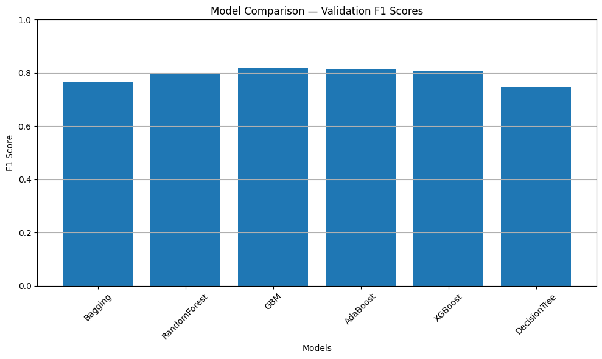

```python
# Extract F1 scores and model names
f1_scores = [perf['F1'].values[0] for perf in performance_orig_val]
model_names = [perf['Model'].iloc[0].replace("_Orig", "") for perf in performance_orig_val]

# Plot
plt.figure(figsize=(10, 6))
plt.bar(model_names, f1_scores)
plt.title("Model Comparison — Validation F1 Scores")
plt.xlabel("Models")
plt.ylabel("F1 Score")
plt.ylim(0, 1)
plt.grid(axis='y')
plt.xticks(rotation=45)
plt.tight_layout()
plt.show()
```

#### **Comment:**

- Base on the plot, GBM or AdaBoost would be the best for shortlisting candidates, and Random Forest or XGBoost as alternatives in ensemble or fallback layers. While Decision Tree to explanation or rule derivation.